# R Homework Assignment 3

Jeeban Panthi, Tiare Fridrich, Mamoon Y. Ismail

2018-04-01

# Introduction

Time-series data for a small mammal community in southern Arizona. Studying the effects of rodents and ants on the plant community that has been running for almost 40 years.Analyzing the the dataset to investigate trends and relationships. Removed the NAs, which left only the rodent taxa.

## Global Options

```r
knitr::opts_chunk$set(echo = TRUE, warning=FALSE, message=FALSE,
                      fig.width=12, fig.height=8, fig.path='figs/')
```

## Session Info:

```r
library(tidyverse)
library(ggplot2)
library(lubridate)
library(gridExtra)
library(dplyr)
library(ggpubr)
library(Hmisc)
#want the output to be hidden but not the packages?
```

## Reading Data

```r
surveys <- read_csv("https://ndownloader.figshare.com/files/2292169")
surveys_NAsrem <- surveys %>% filter(!is.na(weight), !is.na(hindfoot_length), !is.na(sex), species_id != "")
```

# Plots

### 1. Count of females and males of each species observed

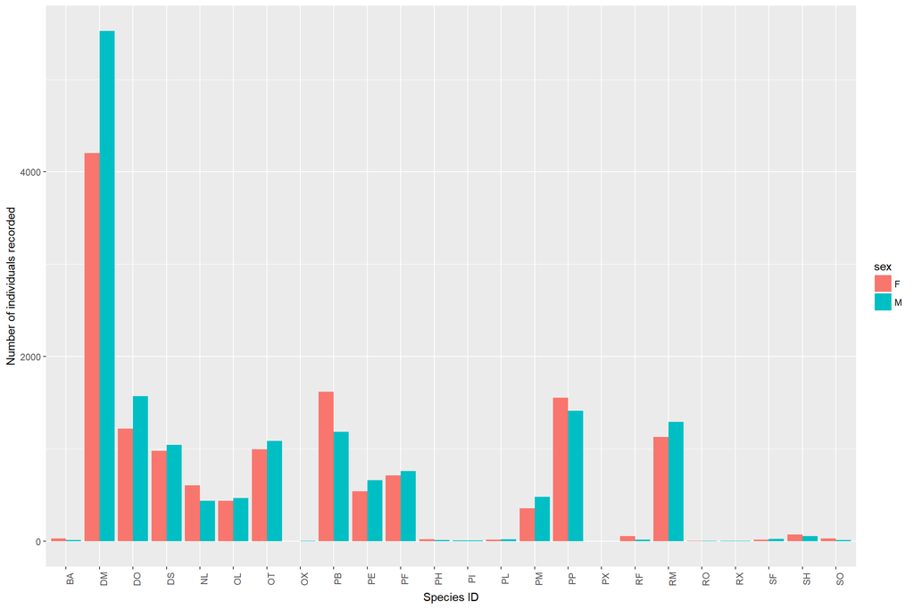

```r
ggplot(surveys_NAsrem) + stat_count(aes(x = species_id, fill = sex), position = "dodge")+ylab('Number of individuals recorded')+xlab('Species ID')+theme(axis.text.x = element_text(angle = 90))
```

Figure 1: Number of individuals of each of the species classfied by sex.

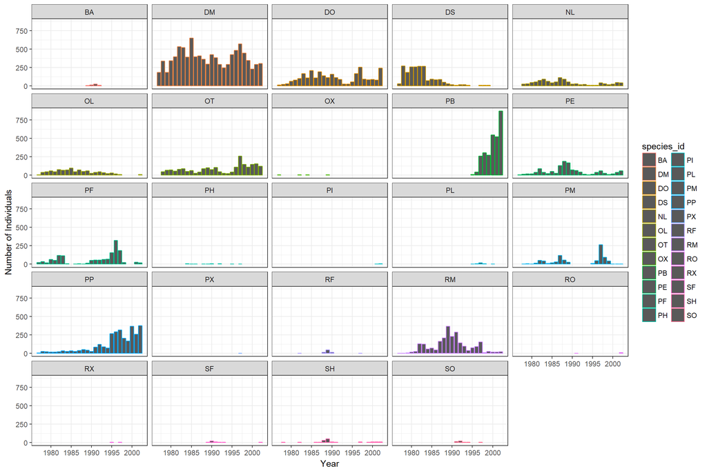

```r
yearly_counts <- surveys_NAsrem %>% group_by(year, species_id) %>% tally()
ggplot(data = yearly_counts, aes(x=year, y=n, group = species_id, color = species_id)) +
  geom_col() + facet_wrap(~ species_id) + theme_bw() +ylab('Number of Individuals') + xlab('Year')
```

Figure 2: Time series faceting plot showing the count of each species yearly.

### 3. Number of individuals observed over time separated by sex

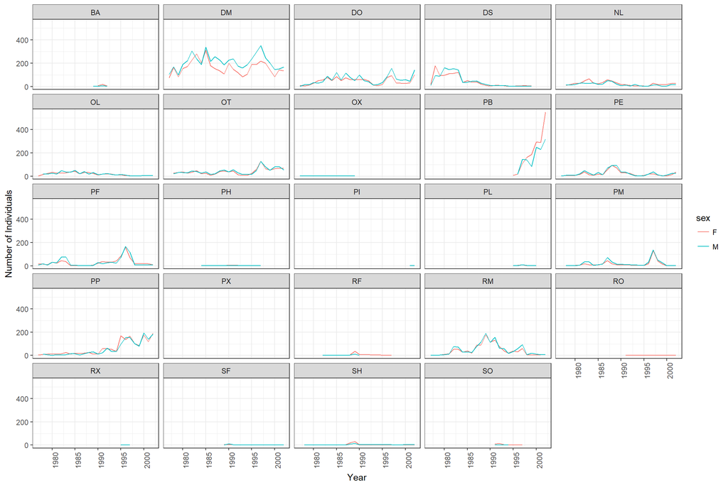

```r
yearly_sex_counts <- surveys_NAsrem %>% group_by(year, species_id, sex) %>%
  tally
ggplot(data = yearly_sex_counts, aes(x = year, y = n, color = sex, group = sex)) +
  geom_line() +
  facet_wrap(~ species_id) +
  theme_bw() +ylab('Number of Individuals') + xlab('Year')+ theme(axis.text.x = element_text(angle = 90))
```

Figure 3: Number of individuals of each sex observed over time, separated by species

### 4. Number of individuals surveyed each year by plot type

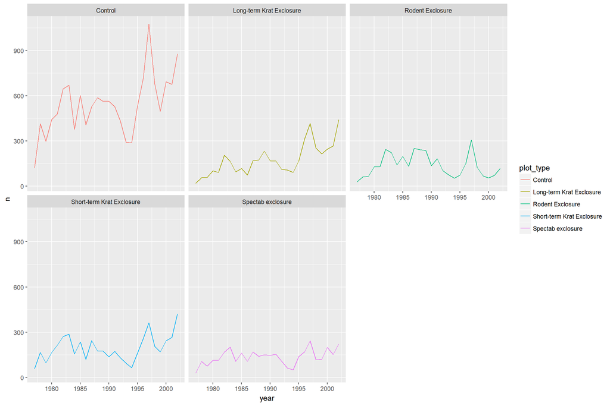

```r
Plot_counts <- surveys_NAsrem %>% group_by(year, plot_type) %>% tally()
ggplot(Plot_counts, aes(x=year, y=n, color=plot_type)) + geom_line()+facet_wrap(~plot_type)
```

Figure 4: Time series faceting plot showing the count of individuals observed in each plot type yearly.

### 5. Hindfoot length of different species

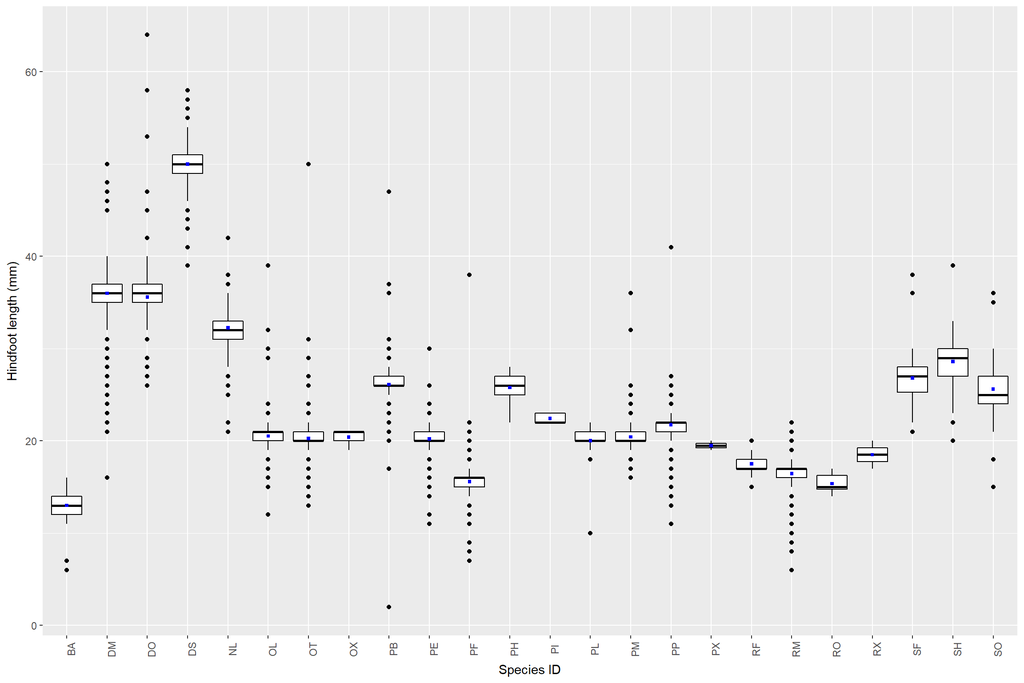

```r
ggplot(surveys_NAsrem, aes(x = species_id, y = hindfoot_length)) +
  geom_boxplot(alpha=1, color= 'black')+xlab('Species ID')+ylab('Hindfoot length (mm)')+
  stat_summary(fun.y=mean, color="blue", geom="point",  shape=15, size=1,show_guide = T,show.legend = T)+ theme(axis.text.x = element_text(angle = 90))
```

Figure 5: Box plot of hindfoot length of different species. The blue dot indicates the average (mean) hindfoot length.

### 6. Relationship between sex and hindfoot length

[figure not shown]

```r
ggplot(surveys_NAsrem, aes(x=sex, y=hindfoot_length))+
  geom_boxplot(alpha = 1,color='blue')+xlab('Sex')+ylab('Length of hindfoot (inch)')+
  stat_summary(fun.y=mean, color="red", geom="point", shape=15, size=1,show_guide = T, show.legend = T) + theme_bw()
```

Figure 6: Hindfoot length for male and female. The red dots indicate the mean (average) hindfoot length.

### 7. Males and females average weight over time

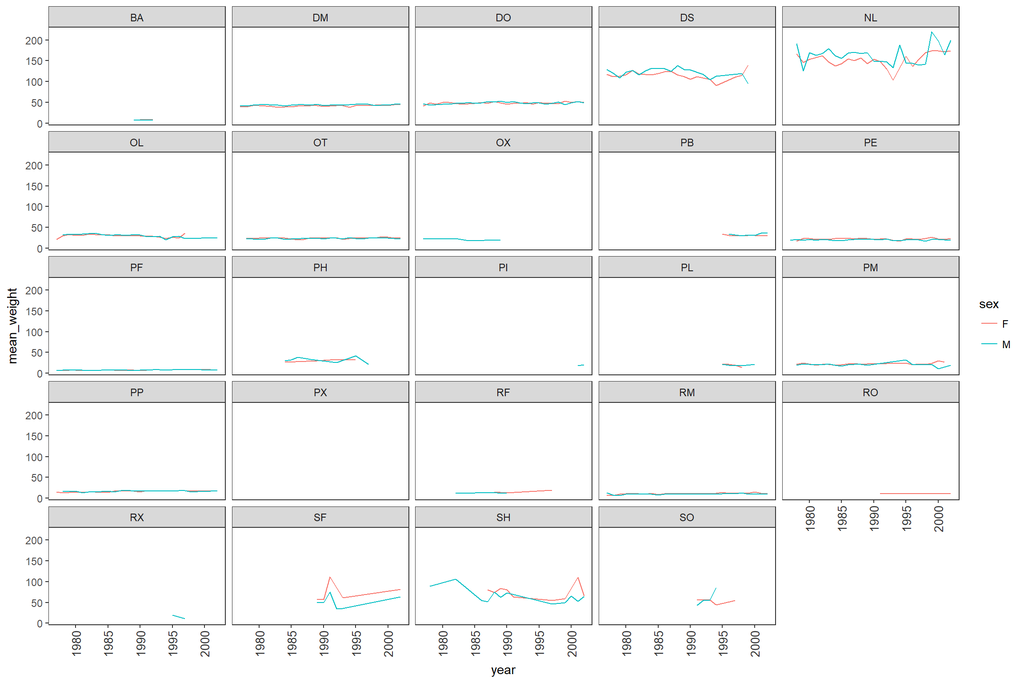

```r
spe_meanweight <- surveys_NAsrem %>% group_by(year,species_id, sex) %>%
  mutate(mean_weight = mean(weight))
ggplot(spe_meanweight, aes(x=year, y=mean_weight, color=sex)) +
  geom_line()+facet_wrap(~species_id) + theme_bw() +
  theme(panel.grid = element_blank()) +
  theme(axis.text.x = element_text(colour = "grey20", size = 10, angle = 90, hjust = 0.5, vjust = 0.5))
```

Figure 7: time series faceting plot showing yearly average weight of each male and female species.

### 8. Correlationship between weight and hindfoot length

[figure not shown]

```r
ggscatter(surveys_NAsrem, x = "weight", y = "hindfoot_length", color = "red", shape = 21, size = 2, add = "reg.line", conf.int = TRUE, cor.coef = TRUE, cor.method = "pearson",  xlab = "Hindfoot Length (mm)", ylab = "Weight (gram)")
```

Figure 8: Scatter plot showing the correlation between weight and hindfoot length of species

The p-value of the test is less than the significance level alpha = 0.05. We can conclude that weight and hindfoot length are significantly positively correlated with a correlation coefficient of 0.68 and p-value of 2.2*10^{-16}

### 9. Relationship between hindfoot length and weight of species OT

[figure not shown]

```r
species_OT <- surveys_NAsrem %>% filter(species_id == 'OT')
ggscatter(species_OT, x = "weight", y = "hindfoot_length", color = "blue", shape = 21, size = 2, add = "reg.line", conf.int = TRUE,
          cor.coef = TRUE, cor.method = "pearson",  xlab = "Hindfoot Length (mm)", ylab = "Weight (gram)")
```

Figure 9: Relationship between hindfoot length and weight of individuals for species OT.

### 10. relationship between species weight and sex

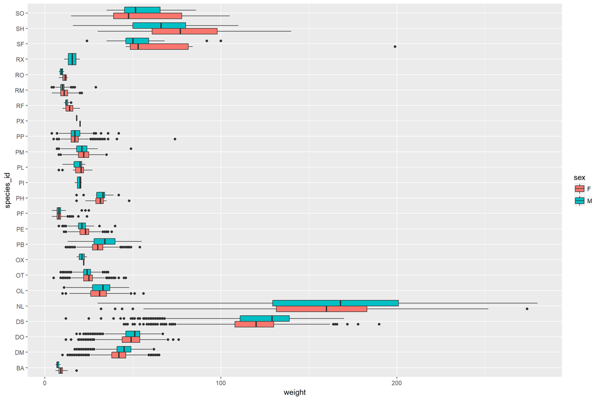

```r
#this one looks a little weird, gotta play around with it
ggplot(surveys_NAsrem) + geom_boxplot(aes(x = species_id, y = weight, fill = sex)) +
  coord_flip()
```

Figure 10: Box plot (axis fliped) showing the relationship between species sex and weight